# Fenómenos físicos asociados

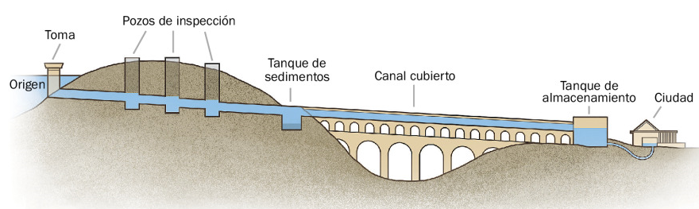

Acueducto romano. Fuente: [jw.org](https://www.jw.org/es/biblioteca/revistas/g201411/acueductos-romanos-ingenier%C3%ADa/)

## Introducción

El agua es uno de los elementos más necesarios para que se desarrolle la vida humana no solo a nivel individual sino también a nivel social en los pueblos, ciudades, etc. Como puedes ver en este [video](https://www.youtube.com/watch?v=6UGZVy3CyOM) los acueductos romanos (y no solo romanos) son una muestra del ingenio humano logró llevar y administrar el agua desde la antiguedad. En esta unidad aprenderás sobre las instalaciones de agua y en esta primera guía verás algunos fenómenos y magnitudes físicas que te ayudarán a comprender mejor lo que viene después.

## Algunas magnitudes físicas

Aquí simplemente nombramos algunas, supuestamente conocidas, que se explican en clase pero que también puedes profundizar por tu cuenta:

- **Presión hidrostática**: Es la presión que se ejerce sobre un punto en un líquido en reposo, también se llama presión estática. En [es.khanacademy.org](https://es.khanacademy.org/science/physics/fluids/density-and-pressure/a/pressure-article) puedes ver una explicación clara.
- **Presión dinámica:** Es la que se produce un fluído en movimiento. Por ejemplo cuando sacas la mano del auto sobre tu mano no solo actúa la presión atmósférica (presión estática del aire en este caso) sino también la presión que ejerce el aire que pega en tu mano a una cierta velocidad.
- **Caudal:** Caudal es la cantidad de fluido que pasa por un punto en un tiempo determinado, normalmente expresado en litros por minuto (L/min) o metros cúbicos por hora (m³/h).

## Algunos fenómenos físicos

Aquí simplemente se nombran algunos que se explicaron en clase y es importante que entiendas.

- Golpe de ariete
- Vasos comunicantes
- Termosifón
- Capilaridad

## Ejemplo de cálculo de la presión hidrostática

En el cálculo de la presión hidrostática es clave determinar la distancia que hay desde el **nivel superior** del agua hasta el punto considerado.

*Ejemplo:* ¿Qué presión hidrostática ejerce el agua del mar sobre una persona que bucea a 8 metros de profundidad? Exprese el resultado en Kgf/cm2.

- Desde el nivel del mar (el nivel superior en este caso) hasta el buzo hay 8 metros.
- Aquí la fórmula fundamental es: `P = Pe * h` donde:
  - P: Presión
  - Pe: Peso específico del agua, en este caso lo aproximamos como 1 Kgf/dm3
  - h: altura o distancia entre el nivel superior y el buzo, es decir 8 metros
- Entonces:
  - P = 1 Kgf/dm3 * 8 m * (100 cm / 1 m) * (1 dm3 / 1000 cm3)
  - P = (8 * 100) / (1000) [Kgf/cm2]
  - **Rta: P = 0,8 [Kgf/cm2]**